# Principal Component Anaysis

## PCA Example in an Intelligent Tutoring System

Next, let's see a real world example: We will be using data from the Assistments Intelligent Tutoring system. This system gives students hints based on how they perform on math problems. We want to see if we can build a decision tree to help teachers decide which students to follow up with, based on students' performance in Assistments.

Here are the variables:

- `id` - student id
- `prior_prob_count` - The number of problems a student has done in the system prior to the current session
- `prior_percent_correct` - The percentage of problems a student has answered correctly piror to the current session
- `problems_attempted` - The number of problems a student has attempted in this current session
- `mean_correct` - The percentage of correct problems in this currect session
- `mean_hint` - The average number of hints the student requested in the current session
- `mean_attempt` - The average attempts for each problem
- `mean_confidence` - The reported confidence a student has reported at the end of the session

```python
ICEdata = pd.read_csv("ICE6_Data.csv")
ICEdata
```

|  | id | prior_prob_count | prior_percent_correct | problems_attempted | mean_correct | mean_hint | mean_attempt | mean_confidence |
| --- | --- | --- | --- | --- | --- | --- | --- | --- |
| 0 | 172777 | 650 | 0.723077 | 4 | 1.000000 | 0.000000 | 1.000000 | 0.550159 |
| 1 | 175658 | 1159 | 0.800690 | 22 | 0.454545 | 2.227273 | 1.227273 | 0.437515 |
| 2 | 175669 | 1239 | 0.656981 | 11 | 0.636364 | 1.363636 | 1.727273 | 0.511060 |
| 3 | 176151 | 1246 | 0.729535 | 16 | 0.750000 | 0.562500 | 1.187500 | 0.491578 |
| 4 | 176165 | 1299 | 0.568129 | 6 | 0.333333 | 2.166667 | 2.000000 | 0.409887 |
| ... | ... | ... | ... | ... | ... | ... | ... | ... |
| 337 | 253464 | 9 | 0.222222 | 23 | 0.782609 | 0.000000 | 1.347826 | 0.602103 |
| 338 | 253517 | 6 | 0.833333 | 16 | 0.562500 | 0.562500 | 2.062500 | 0.571269 |
| 339 | 255494 | 12 | 0.750000 | 3 | 0.666667 | 0.666667 | 1.333333 | 0.563379 |
| 340 | 256227 | 84 | 0.678571 | 3 | 0.333333 | 1.666667 | 1.333333 | 0.567501 |
| 341 | 257289 | 20 | 1.000000 | 4 | 1.000000 | 0.000000 | 1.000000 | 0.439283 |

342 rows × 8 columns

```python
ICEdata_noid = ICEdata.drop(['id'], axis = 1)
icepca = PCA(n_components=7)
icepca.fit(ICEdata_noid)

print("The principal components are:")
print(icepca.components_)
print("The explained variances are:")
print(icepca.explained_variance_)
```

```
The principal components are:
[[ 9.99998379e-01  3.25231653e-05  1.72229676e-03  6.65415156e-05
   4.97054823e-04  1.49367002e-04  1.15030348e-05]
 [-1.73541120e-03  1.03037706e-03  9.99602228e-01  2.30861751e-03
   2.23020180e-02  1.69662730e-02 -8.64582845e-04]
 [-3.87330335e-04 -3.27396081e-02 -2.70451869e-02 -1.24635620e-01
   6.73010236e-01  7.27812593e-01  2.92226368e-03]
 [ 2.29120283e-04  3.26414469e-02  3.68040760e-03  1.78860696e-01
  -7.05688901e-01  6.84765009e-01  5.46329794e-03]
 [ 1.63571033e-04 -1.96336169e-01  6.70115719e-03 -9.52166155e-01
  -2.19898499e-01  3.19977181e-02 -7.35362922e-02]
 [ 1.91456302e-05 -9.79282671e-01  7.60612436e-04  1.99617334e-01
  -2.17110326e-03 -7.96442781e-03  3.30097853e-02]
 [ 1.73255132e-06 -1.78647923e-02 -1.39538358e-03  7.74726598e-02
   1.42375081e-02  3.24800341e-03 -9.96726458e-01]]
The explained variances are:
[1.01909636e+05 9.65917304e+01 8.07223611e-01 4.21069102e-01
 4.13364216e-02 1.60996431e-02 1.08938450e-02]
```

From the explained variances, we can see that the first two components explaining substantially more variances than other components. So let's reduce the the data to two dimensions and plot it.

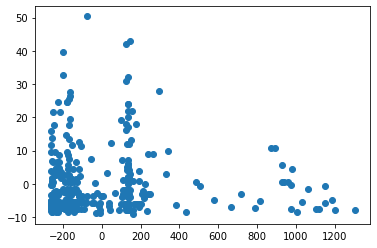

```python
icedata_dr = icepca.transform(ICEdata_noid)
plt.scatter(icedata_dr[:,0], icedata_dr[:,1])
```

From the scatter plot, we can clearly see three clusters. Let's see if KMeans will help us to pick them up.

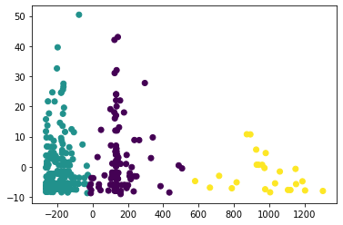

```python
from sklearn.cluster import KMeans

kmeans = KMeans(n_clusters=3)
kmeans.fit(icedata_dr)
cluster_kmeans = kmeans.predict(icedata_dr)

plt.scatter(icedata_dr[:, 0], icedata_dr[:, 1], c=cluster_kmeans, cmap='viridis') # Use cluster_means as the indicator for clusters
```

It looks like the clustering works pretty nicely. So now, it is your turn. Think about two things:

(1) What could the two dimensions mean?

(2) How would you intepret the KMeans clustering?

You should be able to find more clues in this [tutorial](http://strata.uga.edu/8370/lecturenotes/principalComponents.html) by University of Georgia (the implementation is in R, but it has the same idea).

`sklearn` does not support an auto-generation of [biplot](https://blogs.sas.com/content/iml/2019/11/06/what-are-biplots.html) for PCA. So it could be harder to interpret the dimensions. You may need to install `pca` to do it (https://pypi.org/project/pca/) or check this [tutorial](https://newbedev.com/plot-pca-loadings-and-loading-in-biplot-in-sklearn-like-r-s-autoplot) to create a biplot by hand.

PCA result might be influenced by the scale of each variable. So you can also try to scale the variables and run PCA again to compare the difference.

## Final Comments

Given any high-dimensional dataset, I suggest starting with PCA in order to visualize the relationship between points and to understand the main variance in the data. Certainly PCA is not useful for every high-dimensional dataset, but it offers a straightforward and efficient path to gaining insight into high-dimensional data.

PCA's main weakness is that it tends to be highly affected by outliers in the data. For this reason, many robust variants of PCA have been developed, such as `SparsePCA` in `sklearn`.

In addition, PCA, similar to KMeans, is based on the operationalization of distance. So it does not work very well with categorical variables. Sometimes, you may be able to get away with dichotomous variables (therefore, you can do one-hot encoding) and get good enough results. Theoretically, this may not be the best choice. Other methods such as multiple correspondence analysis but the implementation in Python can be complicated. Feel free to read this article to get more practical tips on PCA and related methods in you want to dig deeper:

Nguyen, L. H., & Holmes, S. (2019). Ten quick tips for effective dimensionality reduction. *PLoS computational biology, 15*(6), 1-19.https://doi.org/10.1371/journal.pcbi.1006907

## Your Tasks for ICE 6

1. follow my tutorial and learn how to implement PCA.
2. think about what are you going to do with this method (e.g., implications and applications).
3. keep good record of your ICEs. Save the `.ipynb` files in a same place. You will need them later.